# I/ Descriptive analysis

# 3/ KNN Method

```python
import pandas as pd
df = pd.read_csv('FrequenceOperations.csv')
df.head()
```

|  | Amount | Nombre | Trimester__Calendar | IdOperation |
| --- | --- | --- | --- | --- |
| 0 | 0.0 | 20663 | Trimester1 | 1 |
| 1 | 0.0 | 1648 | Trimester1 | 100 |
| 2 | 0.0 | 1354 | Trimester1 | 101 |
| 3 | 10090.0 | 490 | Trimester1 | 104 |
| 4 | 0.0 | 391211 | Trimester1 | 105 |

```python
df.loc[df['Amount']==0.0 , 'Operation'] = 0
df.loc[df['Amount']!=0.0 , 'Operation'] = 1
```

```python
from sklearn.model_selection import train_test_split
cible = df['Operation']
features = df.drop(['Operation', 'Trimester__Calendar', 'Amount', 'IdOperation'], axis=1)
X_train, X_test, y_train, y_test = train_test_split(features, cible, random_state = 0)
```

```python
# Centrage et réduction
from sklearn.preprocessing import MinMaxScaler
scaler = MinMaxScaler()
X_train = scaler.fit_transform(X_train)
X_test = scaler.fit_transform(X_test)
```

```python
# Choisir le meilleur k
error = []

for i in range(1, 40):
    knn = KNeighborsClassifier(i)
    knn_model = knn.fit(X_train, y_train)
    pred_i = knn_model.predict(X_test)
    error.append(np.mean(pred_i != y_test))
```

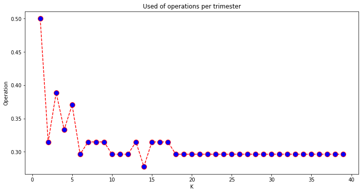

```python
plt.figure(figsize=(12, 6))
plt.plot(range(1, 40), error, color='red', linestyle='dashed', marker='o',
         markerfacecolor='blue', markersize=10)
plt.title('Used of operations per trimester')
plt.xlabel('K')
plt.ylabel('Operation')
```

Pour trouver le k optimal, on va simplement tester le modèle pour tous les k de 1 à 40, mesurer l’erreur test et afficher la performance en fonction de k : Comme on peut le voir, le k-NN le plus performant est celui pour lequel k = 14. On connaît donc notre classifieur final optimal : 14, Ce qui veut dire que cest celui qui classifie le mieux les données.

```python
# Le meilleur k est 14
knn = KNeighborsClassifier(14)
knn_model = knn.fit(X_train, y_train)
y_pred_knn = knn_model.predict(X_test)
# Afficher le score de ce modèle
print('Accuracy of K-NN classifier on training set: {:.2f}'
     .format(knn.score(X_train, y_train)))
print('Accuracy of K-NN classifier on test set: {:.2f}'
     .format(knn.score(X_test, y_test)))
```

```
Accuracy of K-NN classifier on training set: 0.74
Accuracy of K-NN classifier on test set: 0.72
```

*Évaluation de l'algorithme Pour évaluer un algorithme, la matrice de confusion, la précision, le rappel et le score f1 sont les mesures les plus couramment utilisées. Les méthodes confusion_matrix et classification_report de sklearn.metrics peuvent être utilisées pour calculer ces métriques.

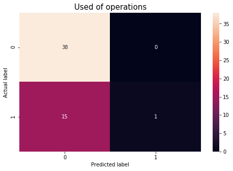

```python
import matplotlib.pyplot as plt
import seaborn as sns
from sklearn import metrics
cm = metrics.confusion_matrix(y_test, y_pred_knn)
plt.figure(figsize=(8,5))
sns.heatmap(cm, annot=True, fmt="d");
plt.ylabel('Actual label');
plt.xlabel('Predicted label');

plt.title('Used of operations', size = 15);
```

Sensibilité = TP/(TP+FN) = 38/(38+15) = 0.71 Une sensibilité égale à 1 signifie que, lorsque l'opération est utilisée fréquemment, il y a 71% de chance que le test de dépistage de l'utilisation soit positif. Spécificité = TN/(TN+FP) = 1/(1+0) = 1 Une spécificité est égale à 1 signifie que, lorsque l'opération n'est pas utilisée fréquemment, il y 100% de chance que le test de dépistage de l'utilisation soit négatif.

TBC = (TP+TN)/Total = (38+1)/54 =0.72 L'algorithme K-NN permet de bien classifier les opérations selon leurs fréquences d’utilisation.

```python
# Affichage du tableau d'évaluation (Precision,Recall, f1-score et support)
from sklearn.metrics import classification_report
print(classification_report(y_test, y_pred_knn))
```

```
              precision    recall  f1-score   support

         0.0       0.72      1.00      0.84        38
         1.0       1.00      0.06      0.12        16

    accuracy                           0.72        54
   macro avg       0.86      0.53      0.48        54
weighted avg       0.80      0.72      0.62        54
```

accuracy c'est la precision general de notre modele : accuracy = F1-Score(de les operations les moins utilisées)-F1-Score(de les operations les plus utilisées ) et puisque accuracy = 0.72 => donc on a un bon classificateur.

# 4/ SVM

```python
from sklearn.svm import SVC, LinearSVC
svc = SVC(probability=True)
svc_model=svc.fit(X_train, y_train)
y_pred_svc = svc_model.predict(X_test)
print('Accuracy of SVM classifier on training set:',svc_model.score(X_train, y_train))
print('Accuracy of SVM classifier on test set:', svc_model.score(X_test, y_test))
```

```
Accuracy of SVM classifier on training set: 0.7358490566037735
Accuracy of SVM classifier on test set: 0.7037037037037037
```

```python
# Matrice de confusion
import matplotlib.pyplot as plt
import seaborn as sns
from sklearn import metrics
cm = metrics.confusion_matrix(y_test, y_pred_svc)
plt.figure(figsize=(8,5))
sns.heatmap(cm, annot=True, fmt="d");
plt.ylabel('Actual label');
plt.xlabel('Predicted label');

plt.title('Used of operations per trimester', size = 15);
```

[output not shown]

```python
# Affichage du tableau d'évaluation (Precision,Recall, f1-score et support)
from sklearn.metrics import classification_report
print(classification_report(y_test, y_pred_svc))
```

```
              precision    recall  f1-score   support

         0.0       0.70      1.00      0.83        38
         1.0       0.00      0.00      0.00        16

    accuracy                           0.70        54
   macro avg       0.35      0.50      0.41        54
weighted avg       0.50      0.70      0.58        54
```

# 4.1/ Linear SVM Method

```python
from sklearn.svm import SVC, LinearSVC
y_test1 = y_test
svc1 = SVC(kernel="linear")
svc1_model=svc1.fit(X_train, y_train)
y_pred_svc1 = svc1_model.predict(X_test)
print('Accuracy of Linear SVM on training set: {:.2f}'
     .format(svc1_model.score(X_train, y_train)))
print('Accuracy of Linear SVM on test set: {:.2f}'
     .format(svc1_model.score(X_test, y_test1)))
```

```
Accuracy of Linear SVM on training set: 0.74
Accuracy of Linear SVM on test set: 0.70
```

```python
cm = metrics.confusion_matrix(y_test1, y_pred_svc1)
plt.figure(figsize=(8,5))
sns.heatmap(cm, annot=True, fmt="d");
plt.ylabel('Actual label');
plt.xlabel('Predicted label');

plt.title('Used of operations per trimester', size = 15);
```

[output not shown]

```python
from sklearn.metrics import classification_report
print(classification_report(y_test1, y_pred_svc1))
```

```
              precision    recall  f1-score   support

         0.0       0.70      1.00      0.83        38
         1.0       0.00      0.00      0.00        16

    accuracy                           0.70        54
   macro avg       0.35      0.50      0.41        54
weighted avg       0.50      0.70      0.58        54
```

# 4.2/ Polynomial SVM Method

## gamma = "auto"

```python
from sklearn.svm import SVC, LinearSVC
svc2 = SVC(kernel="poly",gamma='auto')
svc2_model=svc2.fit(X_train, y_train)
y_pred_svc2 = svc2_model.predict(X_test)
print('Accuracy of SVM Poly classifier on training set:',svc2_model.score(X_train, y_train))
print('Accuracy of SVM Poly classifier on test set:', svc2_model.score(X_test, y_test))
```

```
Accuracy of SVM Poly classifier on training set: 0.7358490566037735
Accuracy of SVM Poly classifier on test set: 0.7037037037037037
```

```python
cm = metrics.confusion_matrix(y_test, y_pred_svc1)
plt.figure(figsize=(8,5))
sns.heatmap(cm, annot=True, fmt="d");
plt.ylabel('Actual label');
plt.xlabel('Predicted label');

plt.title('Used of operations per trimester', size = 15);
```

[output not shown]

```python
from sklearn.metrics import classification_report
print(classification_report(y_test, y_pred_svc2))
```

```
              precision    recall  f1-score   support

         0.0       0.70      1.00      0.83        38
         1.0       0.00      0.00      0.00        16

    accuracy                           0.70        54
   macro avg       0.35      0.50      0.41        54
weighted avg       0.50      0.70      0.58        54
```

## gamma= "scale"

```python
from sklearn.svm import SVC, LinearSVC
svc3 = SVC(kernel="poly",gamma='scale')
svc3_model=svc2.fit(X_train, y_train)
y_pred_svc3 = svc3_model.predict(X_test)
```

```python
print('Accuracy of SVM Poly on training set: {:.2f}'
     .format(svc3_model.score(X_train, y_train)))
print('Accuracy of SVM Poly on test set: {:.2f}'
     .format(svc3_model.score(X_test, y_test)))
```

```
Accuracy of SVM Poly on training set: 0.74
Accuracy of SVM Poly on test set: 0.70
```

```python
cm = metrics.confusion_matrix(y_test, y_pred_svc3)
plt.figure(figsize=(8,5))
sns.heatmap(cm, annot=True, fmt="d");
plt.ylabel('Actual label');
plt.xlabel('Predicted label');

plt.title('Used of operations per trimester', size = 15);
```

[output not shown]

```python
from sklearn.metrics import classification_report
print(classification_report(y_test, y_pred_svc3))
```

```
              precision    recall  f1-score   support

         0.0       0.70      1.00      0.83        38
         1.0       0.00      0.00      0.00        16

    accuracy                           0.70        54
   macro avg       0.35      0.50      0.41        54
weighted avg       0.50      0.70      0.58        54
```

# 6/ Evaluation

# 6.1/ Comparative table

```python
from sklearn.metrics import accuracy_score
# On va afficher un tableau qui ordonne les modèles du plus performant au moins performant suivant le score
acc_svc=accuracy_score(y_test, y_pred_svc)
acc_svc_line=accuracy_score(y_test, y_pred_svc1)
acc_svc_poly_auto=accuracy_score(y_test, y_pred_svc2)
acc_svc_poly_scale=accuracy_score(y_test, y_pred_svc3)
acc_knn=accuracy_score(y_test, y_pred_knn)
models = pd.DataFrame({
    'Model': ['Support Vector Machines' ,'Support Vector Machines Lineaire', 'Support Vector Machines Polynomial Auto',
              'Support Vector Machines Polynomial Scale' ,'KNN'
              ],
    'Score': [acc_svc ,acc_svc_line, acc_svc_poly_auto,
              acc_svc_poly_scale ,acc_knn]})
models.sort_values(by="Score",ascending=False)
```

|  | Model | Score |
| --- | --- | --- |
| 4 | KNN | 0.722222 |
| 0 | Support Vector Machines | 0.703704 |
| 1 | Support Vector Machines Lineaire | 0.703704 |
| 2 | Support Vector Machines Polynomial Auto | 0.703704 |
| 3 | Support Vector Machines Polynomial Scale | 0.703704 |

Notre analyse des l'utilisation des opérations varie également selon les différents modèles testés. ce tableau comparatif montre que les valeurs numériques obtenues pour le score sont de 70%, 70%, 70%, 70% et 72% pour SVM, SVM Lineaire, SVM Plynomial Auto, SVM Plynomial Scale, KNN respectivement. Donc L'analyse comparative montre que les performances du modèle KNN a la prédiction la plus correcte

# 6.2/ Curve Roc

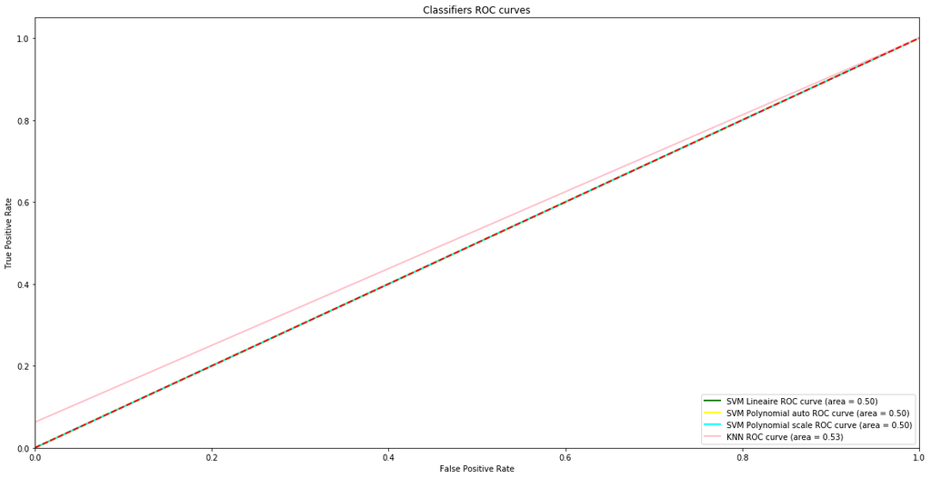

```python
#Affichage avec la bibliothèque graphique intégrée à Notebook
%matplotlib inline

from sklearn.metrics import roc_curve, auc

#fpr1, tpr1, threshold1 = roc_curve(y_test_SVM, y_pred_svc)
#roc_auc1 = auc(fpr1, tpr1)
fpr2, tpr2, threshold2 = roc_curve(y_test1, y_pred_svc1)
roc_auc2 = auc(fpr2, tpr2)
fpr3, tpr3, threshold3 = roc_curve(y_test, y_pred_svc2)
roc_auc3 = auc(fpr3, tpr3)
fpr4, tpr4, threshold4 = roc_curve(y_test, y_pred_svc3)
roc_auc4 = auc(fpr4, tpr4)
fpr5, tpr5, threshold5 = roc_curve(y_test, y_pred_knn)
roc_auc5 = auc(fpr5, tpr5)

plt.figure(figsize=(20,10))
#plt.plot(fpr1, tpr1, color='navy', lw=2, label='SVM ROC curve (area = %0.2f)'% roc_auc1)
plt.plot(fpr2, tpr2, color='green', lw=2, label='SVM Lineaire ROC curve (area = %0.2f)'% roc_auc2)
plt.plot(fpr3, tpr3, color='yellow', lw=2, label='SVM Polynomial auto ROC curve (area = %0.2f)'% roc_auc3)
plt.plot(fpr4, tpr4, color='cyan', lw=2, label='SVM Polynomial scale ROC curve (area = %0.2f)'% roc_auc4)
plt.plot(fpr5, tpr5, color='pink', lw=2, label='KNN ROC curve (area = %0.2f)'% roc_auc5)

plt.plot([0, 1], [0, 1], color='red', lw=2, linestyle='--')
plt.xlim([0.0, 1.0])
plt.ylim([0.0, 1.05])
plt.xlabel('False Positive Rate')
plt.ylabel('True Positive Rate')
plt.title('Classifiers ROC curves')
plt.legend(loc = "lower right")
plt.show()
```

Dans cette figure ou courbe ROC AUC = 0.5 Symbolisée par la diagonale principale dans le graphique (khat ali bil rouge mit9ata3) La courbe de KNN ROC curve (coloré en rose) est toujours « au-dessus» de celle de toutes les autres courbes : elle est meilleur que les methodes de SVM =>Donc la courbe de KNN ROC serait un meilleur modèle de prédiction pour notre objectif(utilisation des operations)

# OBJECTIVE 2.1: Identify the most profitable services

# 1/ Random Forest Method

```python
import pandas as pd
df = pd.read_csv('RentabiliteService1.csv')
df.head()
```

|  | mp_clinet_PK | mp_Service_PK | Trimester__Calendar | Amount |
| --- | --- | --- | --- | --- |
| 0 | 1988201 | 2 | Trimester4 | 0.0 |
| 1 | 1988201 | 2 | Trimester1 | 0.0 |
| 2 | 1988201 | 2 | Trimester1 | 0.0 |
| 3 | 1988201 | 2 | Trimester1 | 0.0 |
| 4 | 1988201 | 2 | Trimester1 | 0.0 |

```python
from sklearn.model_selection import train_test_split
cible = df['mp_Service_PK']
features = df.drop(['mp_Service_PK', 'Trimester__Calendar', 'mp_clinet_PK'], axis=1)
X_train, X_test, y_train, y_test = train_test_split(features, cible, random_state = 0)
```

```python
from sklearn.ensemble import RandomForestClassifier
rfc = RandomForestClassifier()
rfc_model = rfc.fit(X_train, y_train)
y_pred_rfc = rfc_model.predict(X_test)
```

```python
# Afficher le score de ce modèle
print('Accuracy of Random Forest classifier on training set: {:.2f}'
     .format(rfc.score(X_train, y_train)))
print('Accuracy of Random Forest classifier on test set: {:.2f}'
     .format(rfc.score(X_test, y_test)))
```

```
Accuracy of Random Forest classifier on training set: 0.63
Accuracy of Random Forest classifier on test set: 0.63
```

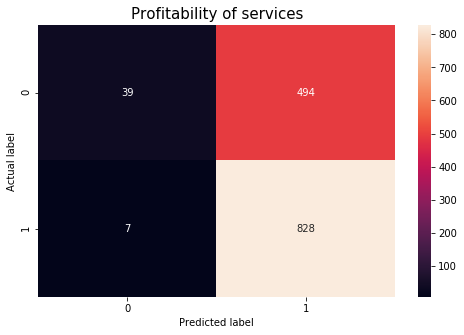

```python
cm = metrics.confusion_matrix(y_test, y_pred_rfc)
plt.figure(figsize=(8,5))
sns.heatmap(cm, annot=True, fmt="d");
plt.ylabel('Actual label');
plt.xlabel('Predicted label');

plt.title('Profitability of services', size = 15);
```

```python
# Affichage du tableau d'évaluation (Precision,Recall, f1-score et support)
from sklearn.metrics import classification_report
print(classification_report(y_test, y_pred_rfc))
```

```
              precision    recall  f1-score   support

           1       0.85      0.07      0.13       533
           2       0.63      0.99      0.77       835

    accuracy                           0.63      1368
   macro avg       0.74      0.53      0.45      1368
weighted avg       0.71      0.63      0.52      1368
```

# 2/ ACP Method

```python
df = pd.read_csv('RentabiliteService.csv')
df.head()
```

|  | mp_clinet_PK | mp_Service_PK | Trimester__Calendar | Amount |
| --- | --- | --- | --- | --- |
| 0 | 1988201 | 2 | Trimester4 | 0.0 |
| 1 | 1988201 | 2 | Trimester1 | 0.0 |
| 2 | 1988201 | 2 | Trimester1 | 0.0 |
| 3 | 1988201 | 2 | Trimester1 | 0.0 |
| 4 | 1988201 | 2 | Trimester1 | 0.0 |

```python
df.describe()
```

|  | mp_clinet_PK | mp_Service_PK | Amount |
| --- | --- | --- | --- |
| count | 3.614193e+07 | 3.614193e+07 | 3.614193e+07 |
| mean | 1.418391e+06 | 1.673853e+00 | 1.382287e+05 |
| std | 8.186644e+05 | 4.692371e-01 | 8.288364e+06 |
| min | 1.000000e+00 | 0.000000e+00 | 0.000000e+00 |
| 25% | 7.119030e+05 | 1.000000e+00 | 0.000000e+00 |
| 50% | 1.431587e+06 | 2.000000e+00 | 0.000000e+00 |
| 75% | 2.121961e+06 | 2.000000e+00 | 0.000000e+00 |
| max | 2.843846e+06 | 2.000000e+00 | 2.000000e+10 |

```python
df = df.iloc[1000:6000,]
df.head()
```

|  | mp_clinet_PK | mp_Service_PK | Trimester__Calendar | Amount |
| --- | --- | --- | --- | --- |
| 1000 | 2158569 | 2 | Trimester1 | 0.0 |
| 1001 | 2158569 | 2 | Trimester1 | 0.0 |
| 1002 | 2158569 | 2 | Trimester1 | 0.0 |
| 1003 | 2158569 | 2 | Trimester1 | 0.0 |
| 1004 | 2158569 | 2 | Trimester1 | 0.0 |

```python
df['Trimester__Calendar'].replace(['Trimester1', 'Trimester2', 'Trimester3', 'Trimester4'], [1, 2, 3, 4], inplace=True)
df.head()
```

|  | mp_clinet_PK | mp_Service_PK | Trimester__Calendar | Amount |
| --- | --- | --- | --- | --- |
| 1000 | 2158569 | 2 | 1 | 0.0 |
| 1001 | 2158569 | 2 | 1 | 0.0 |
| 1002 | 2158569 | 2 | 1 | 0.0 |
| 1003 | 2158569 | 2 | 1 | 0.0 |
| 1004 | 2158569 | 2 | 1 | 0.0 |

```python
df['mp_Service_PK'].replace([1, 2], ['Service Mobicash', 'Service Mobiflouss'], inplace=True)
df
```

|  | mp_clinet_PK | mp_Service_PK | Trimester__Calendar | Amount |
| --- | --- | --- | --- | --- |
| 1000 | 2158569 | Service Mobiflouss | 1 | 0.0 |
| 1001 | 2158569 | Service Mobiflouss | 1 | 0.0 |
| 1002 | 2158569 | Service Mobiflouss | 1 | 0.0 |
| 1003 | 2158569 | Service Mobiflouss | 1 | 0.0 |
| 1004 | 2158569 | Service Mobiflouss | 1 | 0.0 |
| ... | ... | ... | ... | ... |
| 5995 | 1111617 | Service Mobicash | 2 | 0.0 |
| 5996 | 1111617 | Service Mobicash | 2 | 0.0 |
| 5997 | 1111617 | Service Mobicash | 2 | 0.0 |
| 5998 | 1111617 | Service Mobicash | 2 | 0.0 |
| 5999 | 1111617 | Service Mobicash | 2 | 0.0 |

5000 rows × 4 columns

```python
from sklearn.preprocessing import StandardScaler
features = ['Trimester__Calendar', 'Amount']
# Separating out the features
x = df.loc[:, features].values
# Separating out the target
y = df.loc[:,['mp_Service_PK']].values
# Standardizing the features
x = StandardScaler().fit_transform(x)
```

```python
from sklearn.decomposition import PCA
pca = PCA(n_components=2)
principalComponents = pca.fit_transform(x)
principalDf = pd.DataFrame(data = principalComponents
             , columns = ['Amount', 'Trimester'])
```

```python
finalDf = pd.concat([principalDf, df[['mp_Service_PK']]], axis = 1)
```

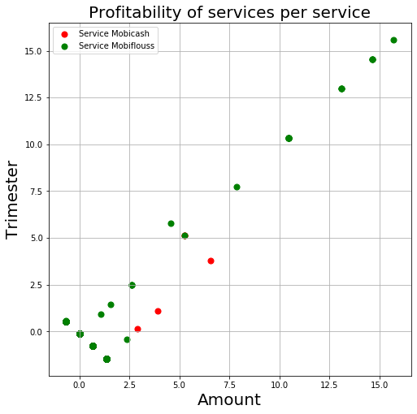

```python
fig = plt.figure(figsize = (8,8))
ax = fig.add_subplot(1,1,1)
ax.set_xlabel('Amount', fontsize = 20)
ax.set_ylabel('Trimester', fontsize = 20)
ax.set_title('Profitability of services per service', fontsize = 20)
targets = ['Service Mobicash', 'Service Mobiflouss']
colors = ['r', 'g']
for target, color in zip(targets,colors):
    indicesToKeep = finalDf['mp_Service_PK'] == target
    ax.scatter(finalDf.loc[indicesToKeep, 'Amount']
               , finalDf.loc[indicesToKeep, 'Trimester']
               , c = color
               , s = 50)
ax.legend(targets)
ax.grid()
```

Le service mobiflouss est corrélé avec l'amount le long des trimestres. Le service mobicash est n'est corrélé avec l'amount qu’au cours des premiers trimestres.  
Le service mobiflouss est plus rentable que le service mobicash.

```python
pca.explained_variance_ratio_
```

```
array([0.50497574, 0.49502426])
```

```python
from sklearn.preprocessing import StandardScaler
features = ['mp_clinet_PK', 'Amount']
# Separating out the features
x = df.loc[:, features].values
# Separating out the target
y = df.loc[:,['mp_Service_PK']].values
# Standardizing the features
x = StandardScaler().fit_transform(x)
```

```python
from sklearn.decomposition import PCA
pca = PCA(n_components=2)
principalComponents = pca.fit_transform(x)
principalDf = pd.DataFrame(data = principalComponents
             , columns = ['Amount', 'Client'])
```

```python
finalDf = pd.concat([principalDf, df[['mp_Service_PK']]], axis = 1)
```

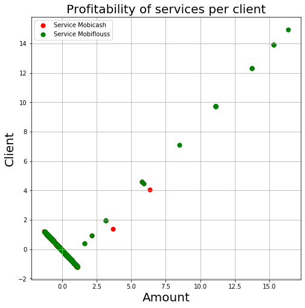

```python
fig = plt.figure(figsize = (8,8))
ax = fig.add_subplot(1,1,1)
ax.set_xlabel('Amount', fontsize = 20)
ax.set_ylabel('Client', fontsize = 20)
ax.set_title('Profitability of services per client', fontsize = 20)
targets = ['Service Mobicash', 'Service Mobiflouss']
colors = ['r', 'g']
for target, color in zip(targets,colors):
    indicesToKeep = finalDf['mp_Service_PK'] == target
    ax.scatter(finalDf.loc[indicesToKeep, 'Amount']
               , finalDf.loc[indicesToKeep, 'Client']
               , c = color
               , s = 50)
ax.legend(targets)
ax.grid()
```

Il existe une forte corrélation entre les clients ,l'amount et le service mobiflouss. Les clients appartenant au service mobiflouss effectuent des opérations rentables. Les clients appartenant au service mobicash sont peu par rapport aux clients du service mobiflouss. Ils effectuent des opérations faiblement rentables.

```python
pca.explained_variance_ratio_
```

```
array([0.53263454, 0.46736546])
```

# 3/ SVM Method

```python
import pandas as pd
df = pd.read_csv('RentabiliteService1.csv')
df.head()
```

|  | mp_clinet_PK | mp_Service_PK | Trimester__Calendar | Amount |
| --- | --- | --- | --- | --- |
| 0 | 1988201 | 2 | Trimester4 | 0.0 |
| 1 | 1988201 | 2 | Trimester1 | 0.0 |
| 2 | 1988201 | 2 | Trimester1 | 0.0 |
| 3 | 1988201 | 2 | Trimester1 | 0.0 |
| 4 | 1988201 | 2 | Trimester1 | 0.0 |

```python
from sklearn.model_selection import train_test_split
cible = df['mp_Service_PK']
features = df.drop(['mp_Service_PK', 'Trimester__Calendar'], axis=1)
X_train, X_test, y_train, y_test = train_test_split(features, cible, random_state = 0)
```

```python
from sklearn.svm import SVC, LinearSVC
svc = SVC(probability=True)
svc_model=svc.fit(X_train, y_train)
y_pred_svc = svc_model.predict(X_test)
print('Accuracy of SVM classifier on training set:',svc_model.score(X_train, y_train))
print('Accuracy of SVM classifier on test set:', svc_model.score(X_test, y_test))
```

```
Accuracy of SVM classifier on training set: 0.6110704706169227
Accuracy of SVM classifier on test set: 0.6103801169590644
```

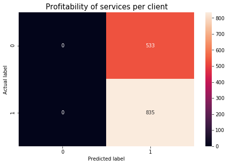

```python
cm = metrics.confusion_matrix(y_test, y_pred_svc)
plt.figure(figsize=(8,5))
sns.heatmap(cm, annot=True, fmt="d");
plt.ylabel('Actual label');
plt.xlabel('Predicted label');

plt.title('Profitability of services per client', size = 15);
```

```python
# Affichage du tableau d'évaluation (Precision,Recall, f1-score et support)
from sklearn.metrics import classification_report
print(classification_report(y_test, y_pred_svc))
```

```
              precision    recall  f1-score   support

           1       0.00      0.00      0.00       533
           2       0.61      1.00      0.76       835

    accuracy                           0.61      1368
   macro avg       0.31      0.50      0.38      1368
weighted avg       0.37      0.61      0.46      1368
```

# 3.1/ Polynomial svm Method

## gamma ="scale"

```python
from sklearn.svm import SVC, LinearSVC
svc1 = SVC(kernel="poly",gamma='scale')
svc1_model=svc1.fit(X_train, y_train)
y_pred_svc1 = svc1_model.predict(X_test)
```

```python
print('Accuracy of SVM Poly on training set: {:.2f}'
     .format(svc1_model.score(X_train, y_train)))
print('Accuracy of SVM Poly on test set: {:.2f}'
     .format(svc1_model.score(X_test, y_test)))
```

```
Accuracy of SVM Poly on training set: 0.61
Accuracy of SVM Poly on test set: 0.61
```

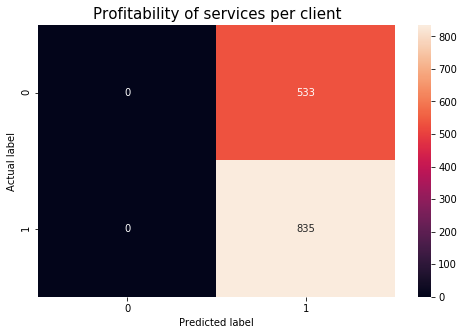

```python
cm = metrics.confusion_matrix(y_test, y_pred_svc1)
plt.figure(figsize=(8,5))
sns.heatmap(cm, annot=True, fmt="d");
plt.ylabel('Actual label');
plt.xlabel('Predicted label');

plt.title('Profitability of services per client', size = 15);
```

```python
from sklearn.metrics import classification_report
print(classification_report(y_test, y_pred_svc1))
```

```
              precision    recall  f1-score   support

           1       0.00      0.00      0.00       533
           2       0.61      1.00      0.76       835

    accuracy                           0.61      1368
   macro avg       0.31      0.50      0.38      1368
weighted avg       0.37      0.61      0.46      1368
```

# 4/ Evaluation

# 4.1/ Comparative table

```python
from sklearn.metrics import accuracy_score
from sklearn.metrics import recall_score
from sklearn.metrics import precision_score
from sklearn.metrics import f1_score
```

```python
# On va afficher un tableau qui ordonne les modèles du plus performant au moins performant suivant le score
acc_svc_line=accuracy_score(y_test, y_pred_svc)
acc_svc_poly=accuracy_score(y_test, y_pred_svc1)
acc_rfc=accuracy_score(y_test, y_pred_rfc)
models = pd.DataFrame({
    'Model': ['Support Vector Machines Lineaire', 'Support Vector Machines Polynomial',
              'Random Forest'
              ],
    'Score': [acc_svc_line, acc_svc_poly,
              acc_rfc]})
models.sort_values(by="Score",ascending=False)
```

|  | Model | Score |
| --- | --- | --- |
| 2 | Random Forest | 0.633772 |
| 0 | Support Vector Machines Lineaire | 0.610380 |
| 1 | Support Vector Machines Polynomial | 0.610380 |